# VOCAL Data Exploration

## 5 Display Rules

Participants from Brazil, the UK, and the Netherlands were asked to rate how appropriate people in their culture would find the vocalisation across two factors:

- Private vs. Public space
- With close others vs. not-close others

|  | Chisq | Df | Pr(>Chisq) |
| --- | --- | --- | --- |
| culture | 15.8749224 | 2 | 0.0003571 |
| close_others_context | 465.8888497 | 1 | 0.0000000 |
| private_context | 30.7579673 | 1 | 0.0000000 |
| culture:close_others_context | 2.6925604 | 2 | 0.2602064 |
| culture:private_context | 0.0564677 | 2 | 0.9721610 |
| close_others_context:private_context | 0.3547708 | 1 | 0.5514248 |
| culture:close_others_context:private_context | 0.1657302 | 2 | 0.9204753 |

Based on the lack of interaction effects involving `close others` I’ve collapsed the data across this factor.

We get a main effects of culture (BR vs. NL vs. UK) and context (private vs. public), but no interaction.

```r
lmer(rating ~ culture * private_context + (1|id), display_rules_data) %>% car::Anova()
```

```
Analysis of Deviance Table (Type II Wald chisquare tests)

Response: rating
                          Chisq Df   Pr(>Chisq)
culture                 15.6324  2    0.0004031 ***
private_context         24.0945  1 0.0000009172 ***
culture:private_context  0.0442  2    0.9781256
---
Signif. codes:  0 '***' 0.001 '**' 0.01 '*' 0.05 '.' 0.1 ' ' 1
```

### 5.1 **In all three cultures, vocalisations are more appropriate in private than public.**

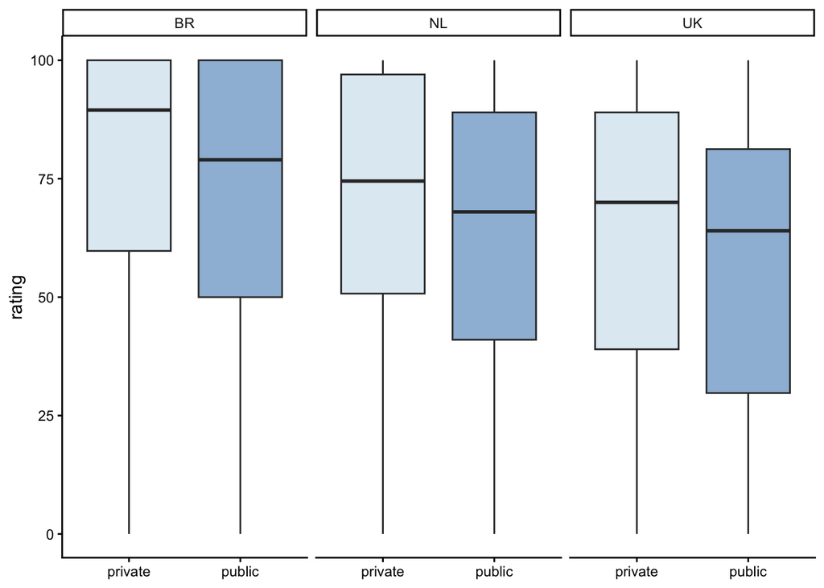

The differences are significant within each of the three cultures.

### 5.2 **Brazilians rate vocalisations as more acceptable than the British (and almost differ from the Dutch too).**

```
 contrast estimate   SE  df t.ratio p.value
 BR - NL      6.53 3.06 158   2.136  0.0860
 BR - UK     12.17 3.09 160   3.935  0.0004
 NL - UK      5.65 2.70 146   2.091  0.0952

Degrees-of-freedom method: kenward-roger
P value adjustment: tukey method for comparing a family of 3 estimates
```

## 6 Perceived Universality

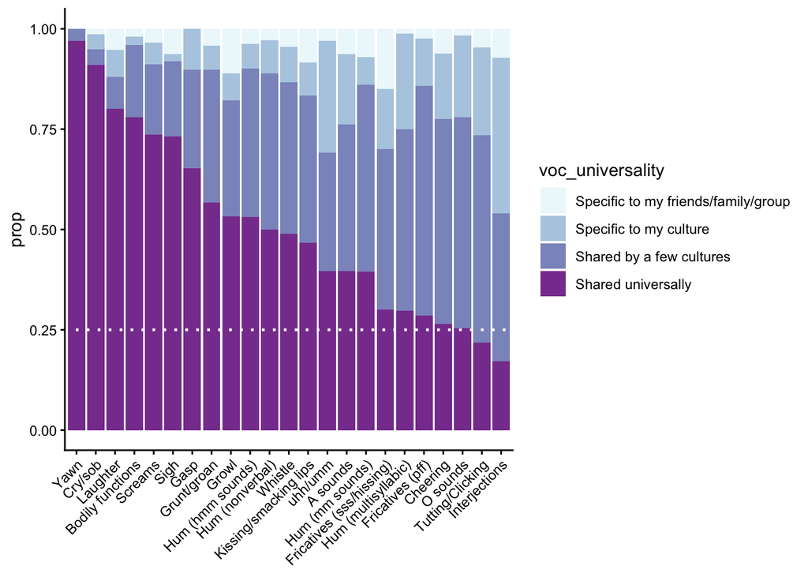

The most-frequently selected universality levels for each category of vocalisation:

| voc_universality | category |
| --- | --- |
| Specific to my culture | Interjections |
| Shared by a few cultures | Hum (mm sounds) |
|  | Fricatives (sss/hissing) |
|  | Hum (multisyllabic) |
|  | Fricatives (pff) |
|  | Cheering |
|  | O sounds |
|  | Tutting/Clicking |
| Shared universally | Yawn |
|  | Cry/sob |
|  | Laughter |
|  | Bodily functions |
|  | Screams |
|  | Sigh |
|  | Gasp |
|  | Grunt/groan |
|  | Growl |
|  | Hum (hmm sounds) |
|  | Hum (nonverbal) |
|  | Whistle |
|  | Kissing/smacking lips |
|  | uhh/umm |
|  | A sounds |

### 6.1 Universality and interpersonal context

I found no relationship between the perceived universality of a vocalisation and how often it was reported to take place with **close others:**

```
    Pearson's Chi-squared test

data:  .
X-squared = 2.2865, df = 3, p-value = 0.5151
```

**Not close others:**

```
    Pearson's Chi-squared test

data:  .
X-squared = 1.742, df = 3, p-value = 0.6276
```

**Or when alone:**

```
    Pearson's Chi-squared test

data:  .
X-squared = 2.4941, df = 3, p-value = 0.4764
```

## 7 Topic modelling

Because we have free-text descriptions of the **context** surrounding a vocalisation (“Describe the **situation** where you made this vocalization.”), and the self-proclaimed **reason** people had for making the vocalisation (“**Why** did you make this vocalization?”), we can do some topic modelling to see if distinct contexts emerge.

The below is a rough-pass LDA: I removed English and Dutch stopwords, and corrected spelling when I caught obvious typos. But otherwise you’ll see that there are some Dutch words mixed into the data, and the lemmatisation could be improved.

**Laughter**

```
Number of vocalisations with descriptions: 82
Best k by AIC: 2
Best k by BIC: 2
Model fit with 2 topics:
```

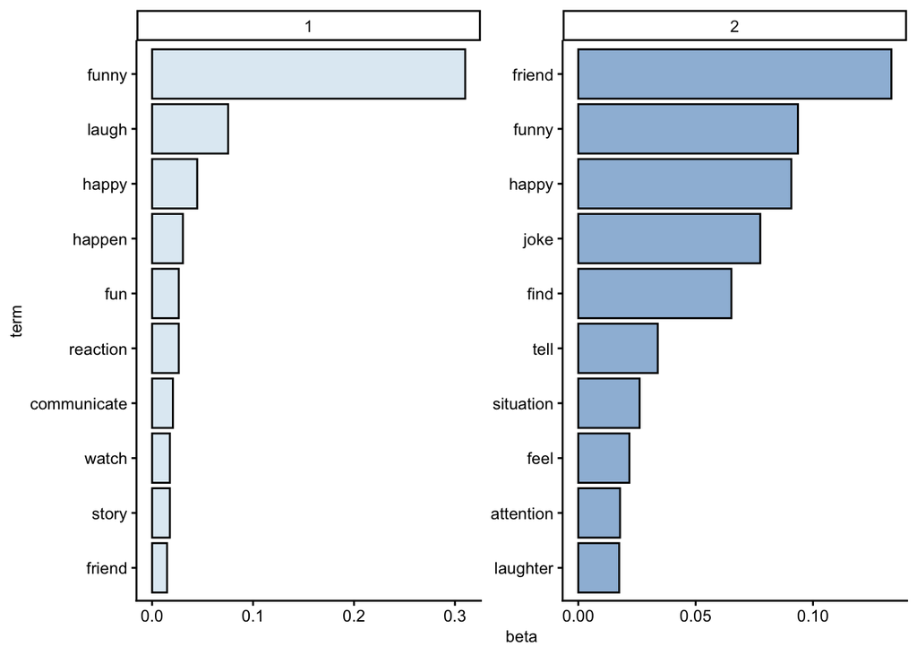

**Crying/Sobbing**

```
Number of vocalisations with descriptions: 19
Best k by AIC: 2
Best k by BIC: 2
Model fit with 2 topics:
```

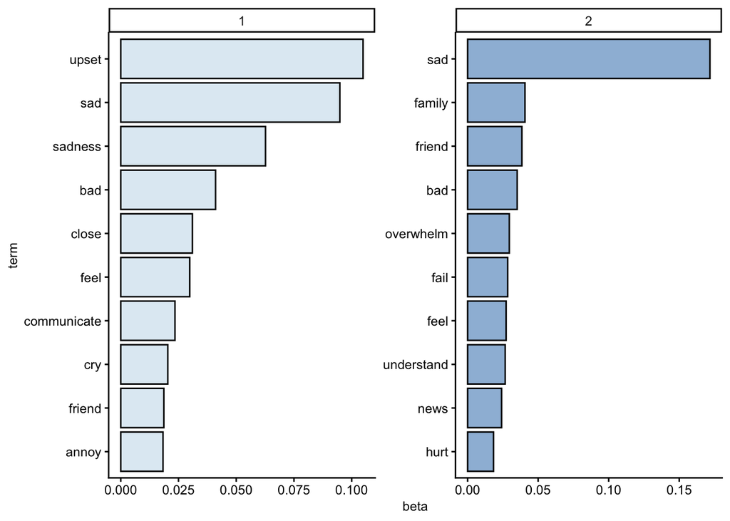

**Screams**

```
Number of vocalisations with descriptions: 15
Best k by AIC: 2
Best k by BIC: 2
Model fit with 2 topics:
```

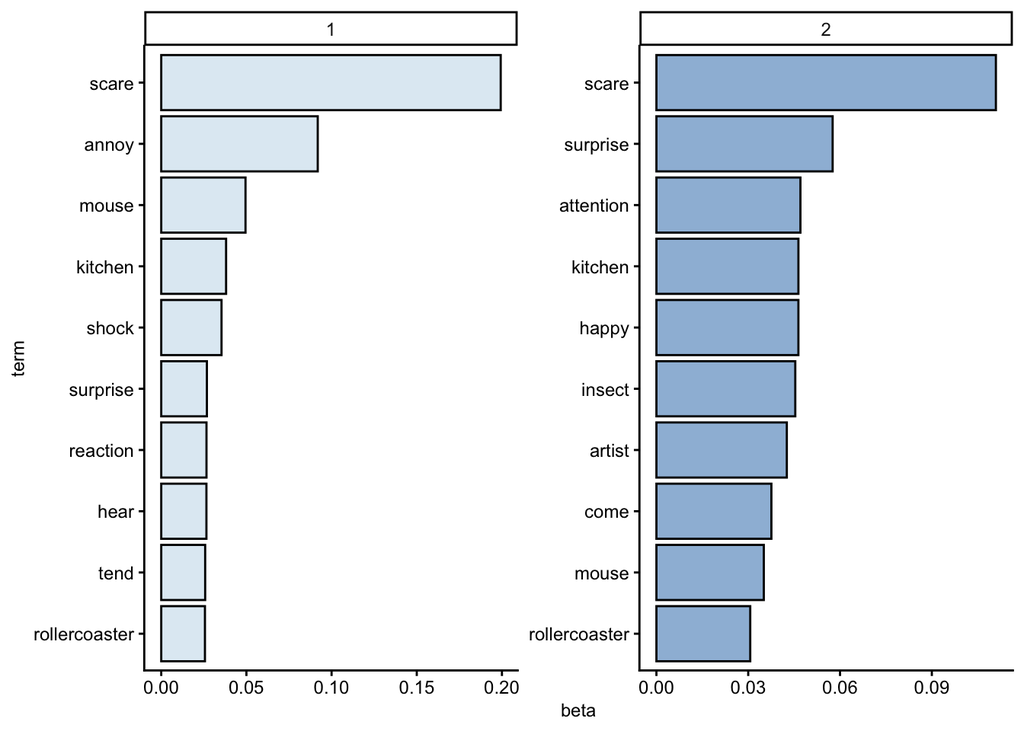

**Bodily functions**

```
Number of vocalisations with descriptions: 17
Best k by AIC: 3
Best k by BIC: 2
Model fit with 3 topics:
```

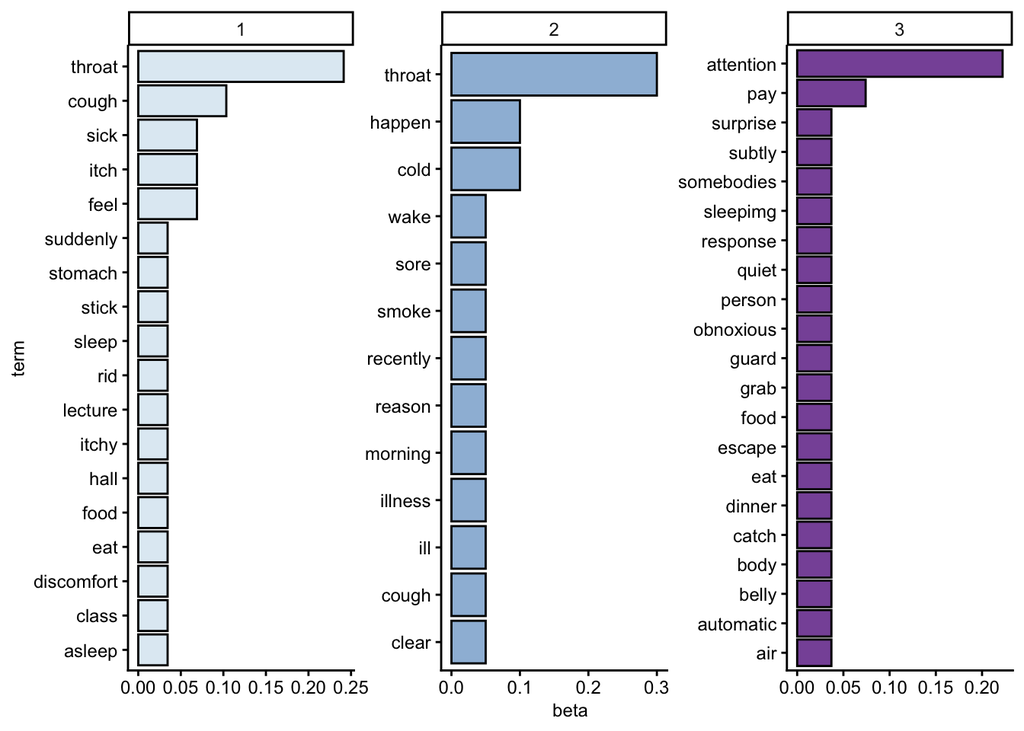

**“Aa” sounds**

```
Number of vocalisations with descriptions: 18
Best k by AIC: 3
Best k by BIC: 2
Model fit with 3 topics:
```

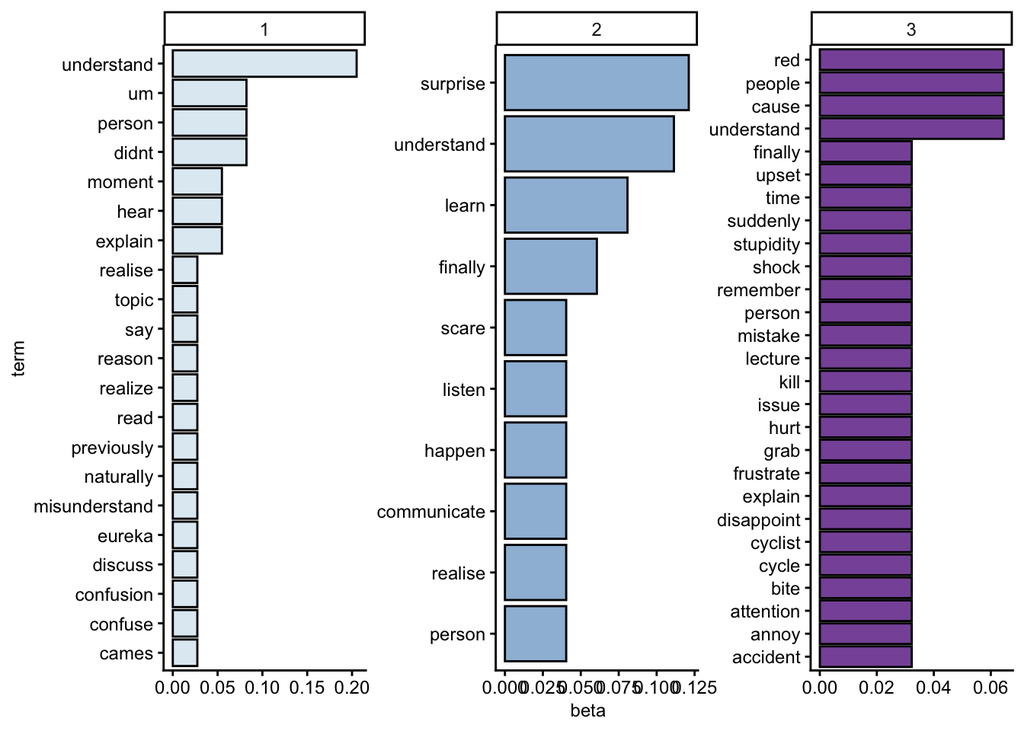

**Grunting/groaning**

```
Number of vocalisations with descriptions: 38
Best k by AIC: 2
Best k by BIC: 2
Model fit with 2 topics:
```

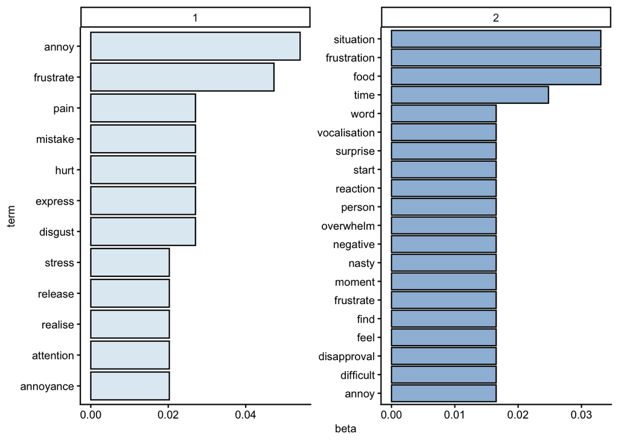

**Yawns**

```
Number of vocalisations with descriptions: 13
Best k by AIC: 2
Best k by BIC: 2
Model fit with 2 topics:
```

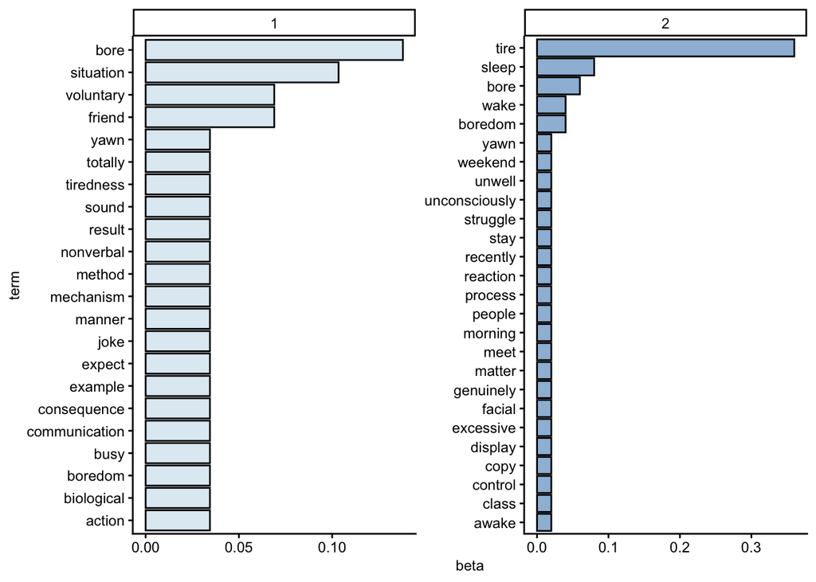

**Gasps**

```
Number of vocalisations with descriptions: 17
Best k by AIC: 3
Best k by BIC: 2
Model fit with 3 topics:
```

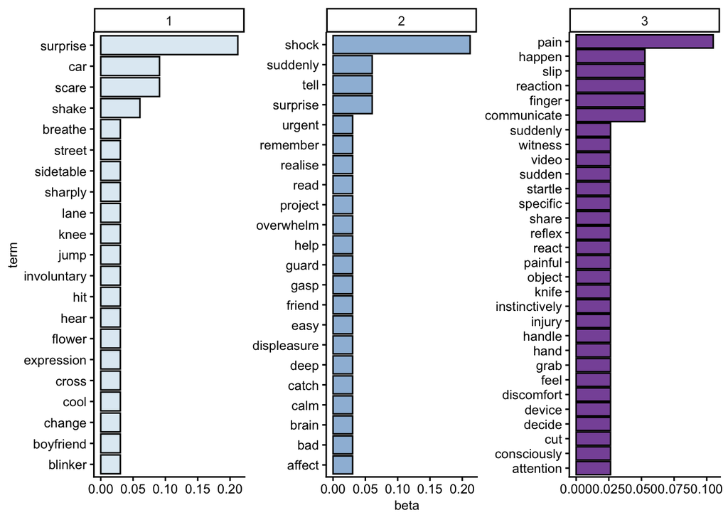

**“O” sounds**

```
Number of vocalisations with descriptions: 14
Best k by AIC: 2
Best k by BIC: 2
Model fit with 2 topics:
```

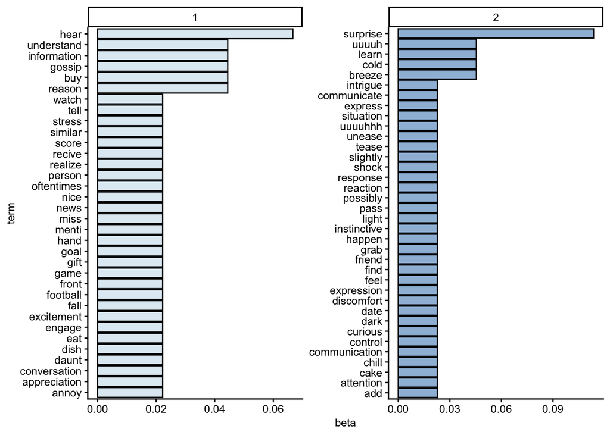

**Multi-syllable hums**

```
Number of vocalisations with descriptions: 27
Best k by AIC: 2
Best k by BIC: 2
Model fit with 2 topics:
```

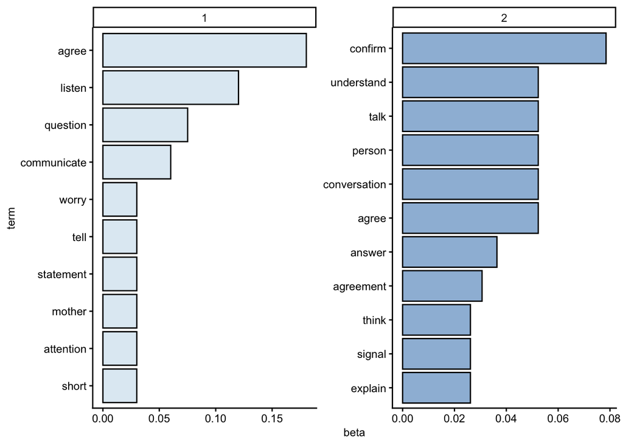

**“Mmm” sounds**

```
Number of vocalisations with descriptions: 14
Best k by AIC: 3
Best k by BIC: 2
Model fit with 3 topics:
```

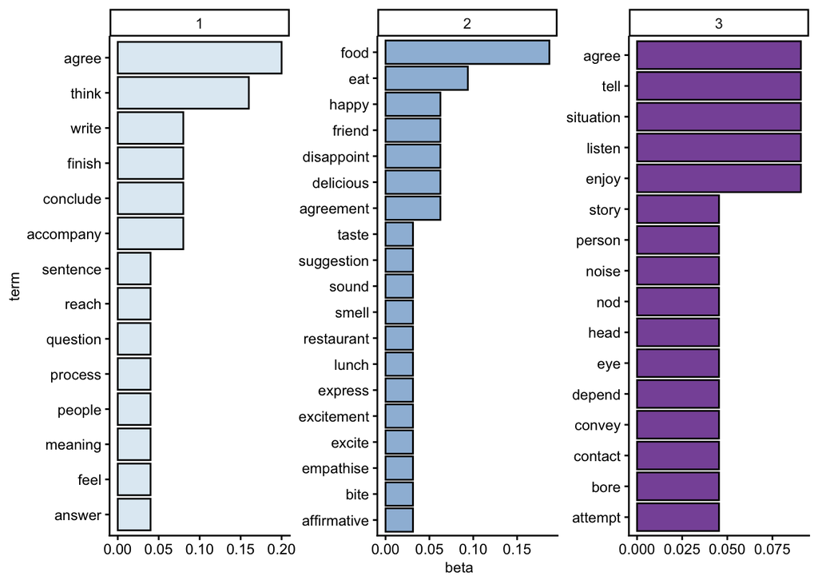

**“Hmm” sounds**

```
Number of vocalisations with descriptions: 25
Best k by AIC: 2
Best k by BIC: 2
Model fit with 2 topics:
```

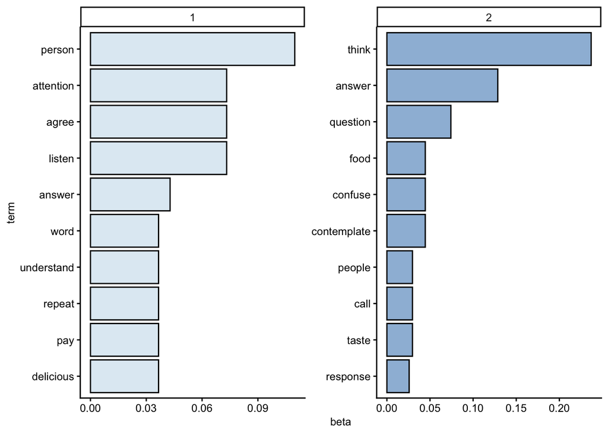

**Humming**

```
Number of vocalisations with descriptions: 11
Best k by AIC: 3
Best k by BIC: 2
Model fit with 3 topics:
```

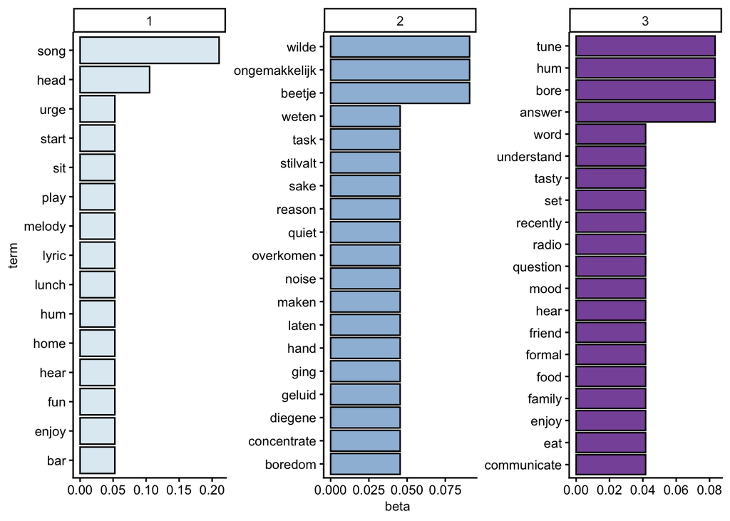

**Lip sounds (kissing/smacking lips)**

```
Number of vocalisations with descriptions: 30
Best k by AIC: 2
Best k by BIC: 2
Model fit with 2 topics:
```

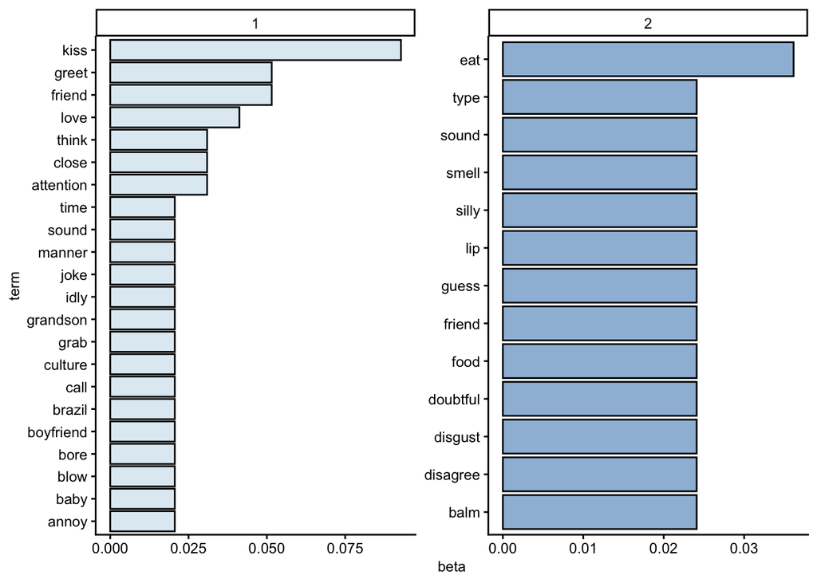

**Filler sounds (uhh/umm)**

```
Number of vocalisations with descriptions: 23
Best k by AIC: 2
Best k by BIC: 2
Model fit with 2 topics:
```

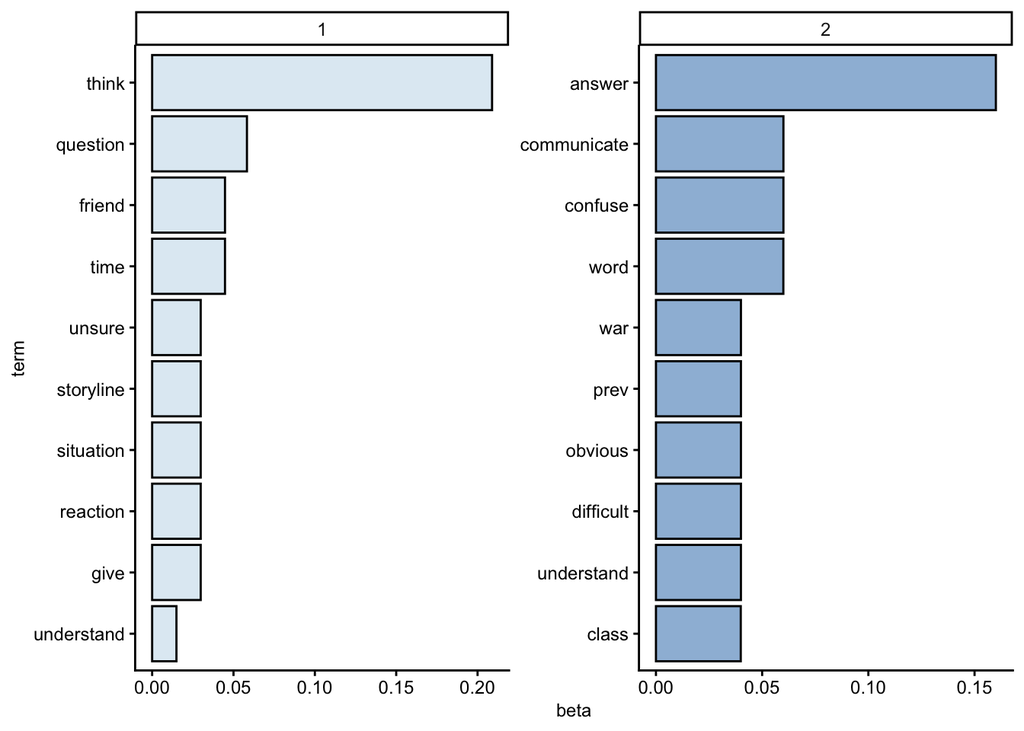

**Sighs**

```
Number of vocalisations with descriptions: 42
Best k by AIC: 2
Best k by BIC: 2
Model fit with 2 topics:
```

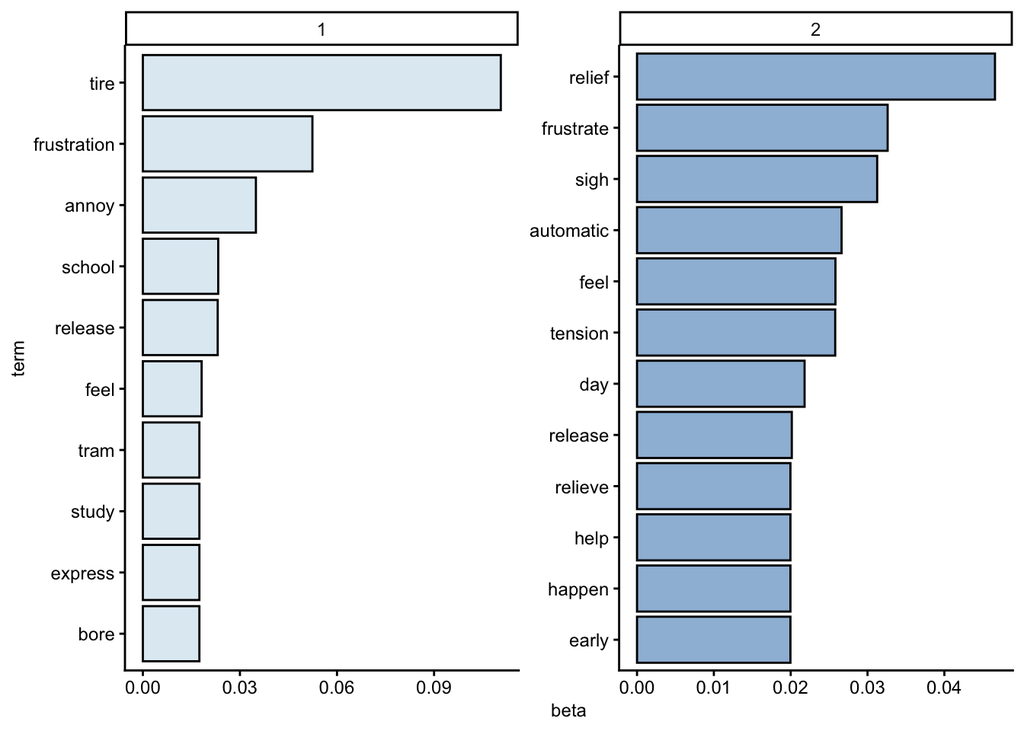

**Expressive Interjections**

```
Number of vocalisations with descriptions: 129
Best k by AIC: 2
Best k by BIC: 2
Model fit with 2 topics:
```

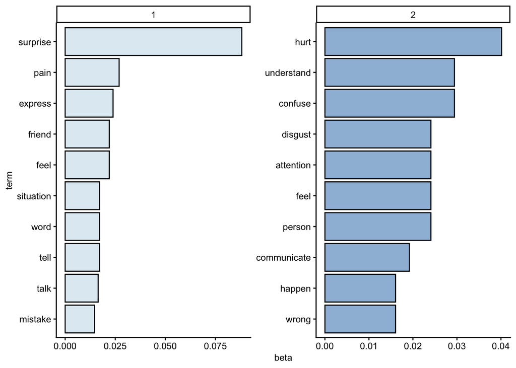

**Cheering**

```
Number of vocalisations with descriptions: 16
Best k by AIC: 2
Best k by BIC: 2
Model fit with 2 topics:
```

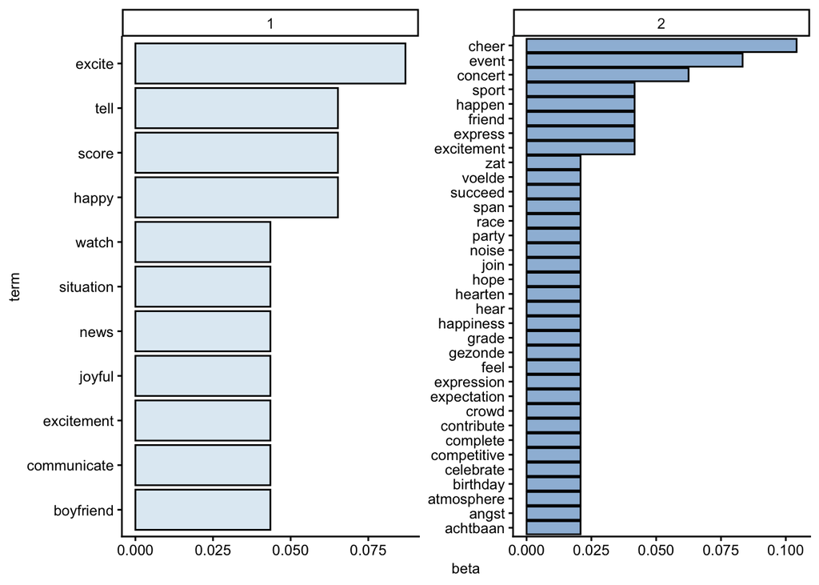

**Hissing**

```
Number of vocalisations with descriptions: 11
Best k by AIC: 2
Best k by BIC: 2
Model fit with 2 topics:
```

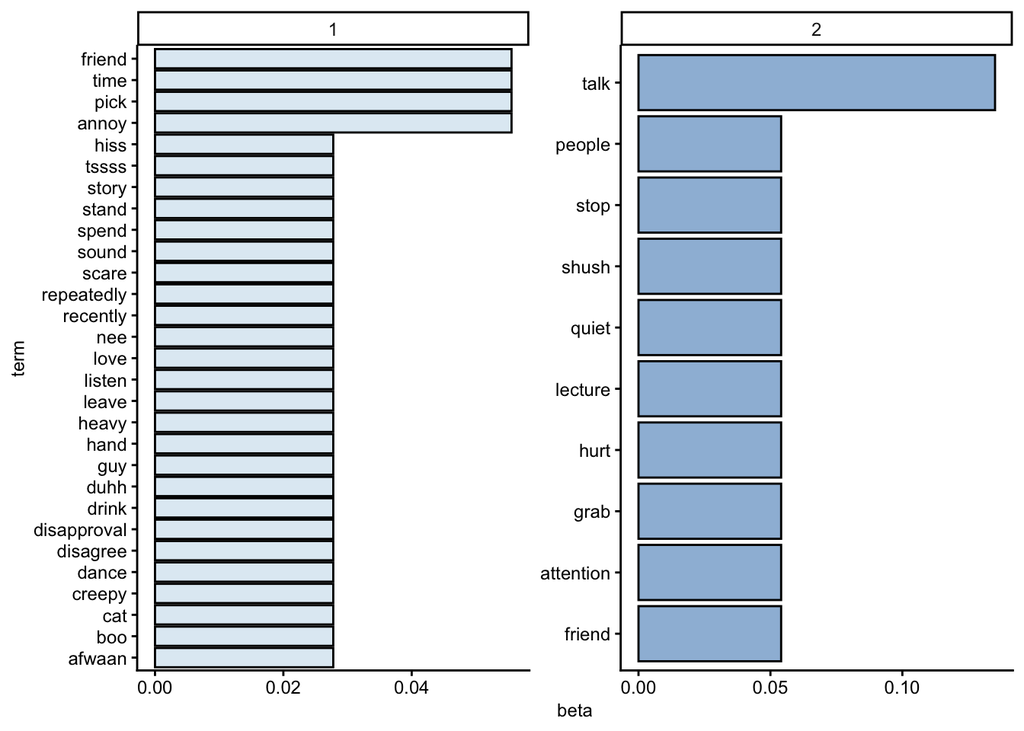

**“Pff” sounds**

```
Number of vocalisations with descriptions: 13
Best k by AIC: 2
Best k by BIC: 2
Model fit with 2 topics:
```

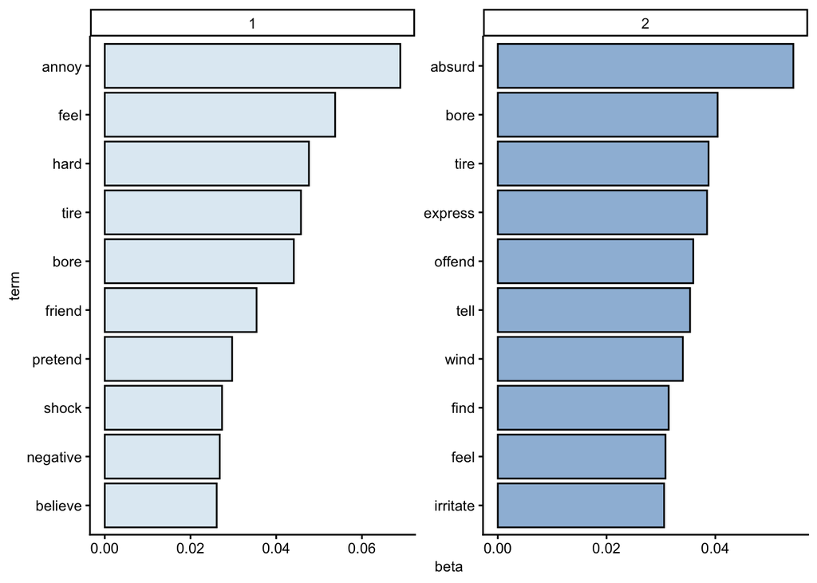

**Growls**

```
Number of vocalisations with descriptions: 14
Best k by AIC: 2
Best k by BIC: 2
Model fit with 2 topics:
```

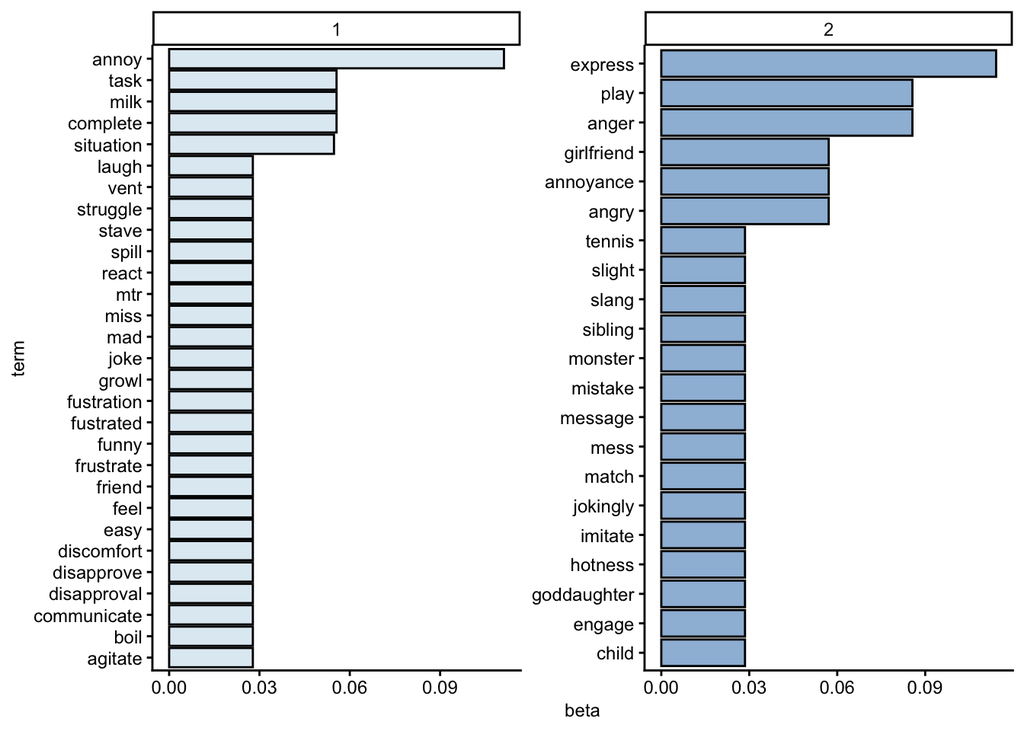

**Tutting/clicking**

```
Number of vocalisations with descriptions: 56
Best k by AIC: 2
Best k by BIC: 2
Model fit with 2 topics:
```

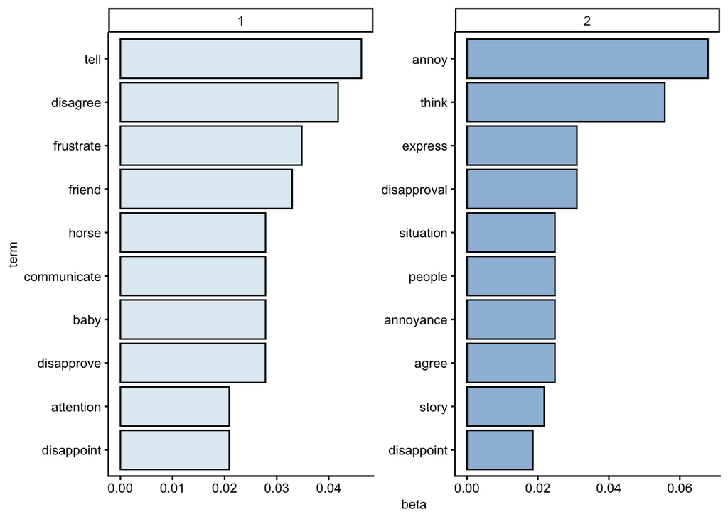

**Whistling**

```
Number of vocalisations with descriptions: 17
Best k by AIC: 2
Best k by BIC: 2
Model fit with 2 topics:
```

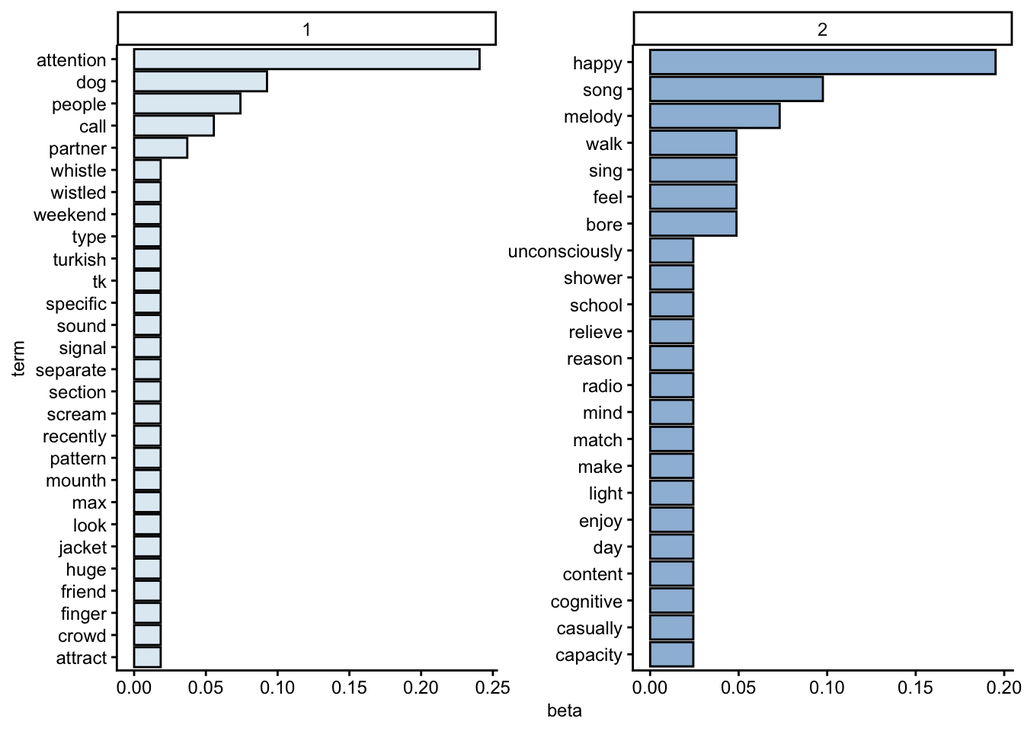

## 8 Plotting similarity in “context space”: MDS

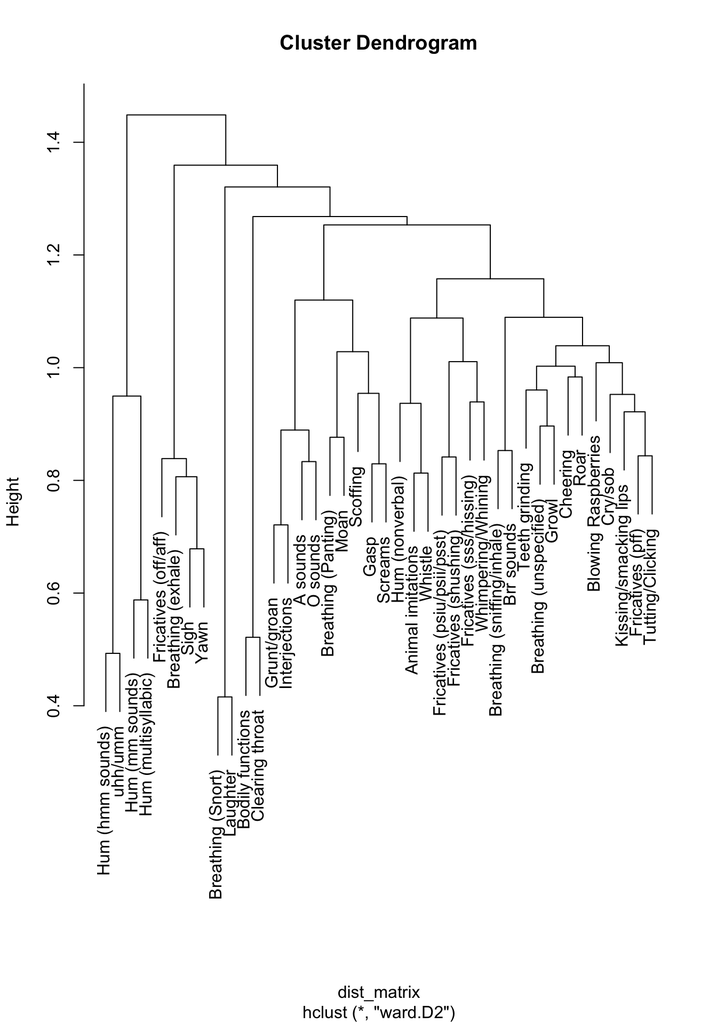

[interactive chart not shown]

## 9 Plotting similarity in “context space”: Heatmap

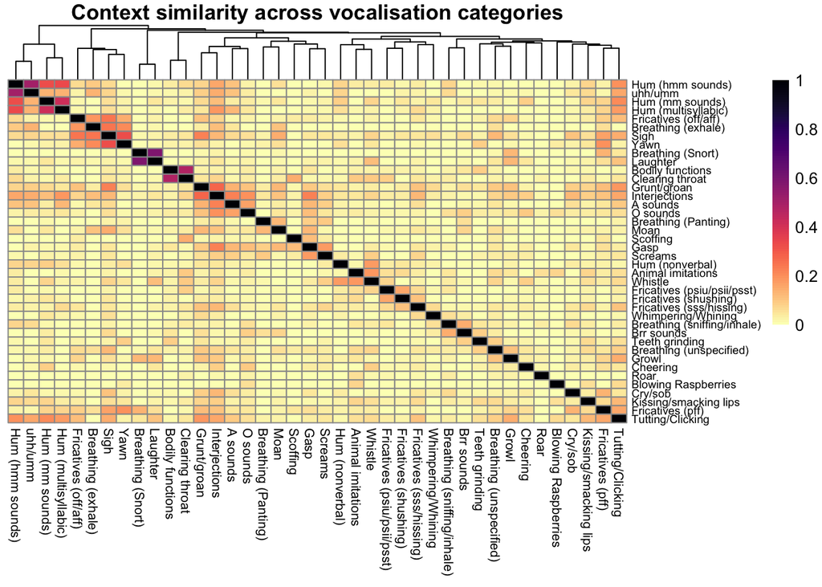

## 10 Plotting similarity in “emotion space”: MDS

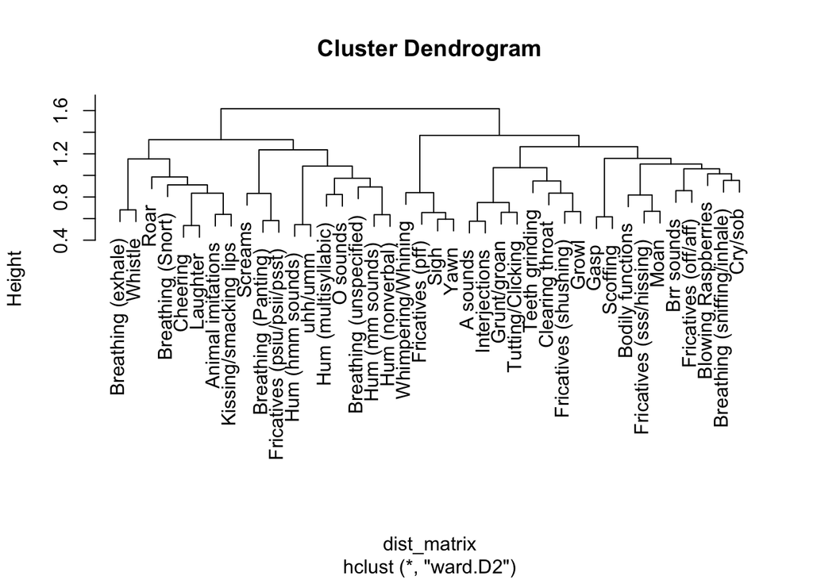

[interactive chart not shown]